Politechnika Gdańska

Wydział Zarządzania i Ekonomii

# Raport: Uzależnienie od social mediów wśród studentów

Dawid Drawc

## Cel i pytania badawcze

Celem raportu jest sprawdzenie, jak **średni dzienny czas korzystania z social mediów** (`Avg_Daily_Usage_Hours`) wiąże się z:

- poziomem uzależnienia (`Addicted_Score`),
- snem (`Sleep_Hours_Per_Night`),
- zdrowiem psychicznym (`Mental_Health_Score`),
- konfliktami przez social media (`Conflicts_Over_Social_Media`),
- deklaracją wpływu na wyniki w nauce (`Affects_Academic_Performance`, Yes/No).

Pytania badawcze:

1. Czy osoby z wyższym czasem korzystania mają wyższy poziom uzależnienia?
2. Czy wyższy czas korzystania wiąże się z krótszym snem?
3. Czy wyższy czas korzystania wiąże się z gorszym zdrowiem psychicznym?
4. Czy wyższy czas korzystania wiąże się z większą liczbą konfliktów?
5. Czy osoby, które mówią „Yes” (wpływa na naukę), różnią się od „No” (czas, sen, uzależnienie itp.)?

## 1. Wstęp i opis danych

Analiza została wykonana na zbiorze danych dotyczących korzystania z mediów społecznościowych przez studentów. Temat jest istotny, ponieważ w grupie studentów intensywne korzystanie z social mediów może nakładać się na obowiązki akademickie, rytm dobowy oraz funkcjonowanie psychiczne. W literaturze często wskazuje się m.in. mechanizmy takie jak: rozproszenie uwagi, odkładanie zadań (prokrastynacja), skracanie snu przez używanie telefonu wieczorem oraz stres społeczny związany z porównywaniem się lub konfliktami online.

Zmienne w zbiorze mają w dużej części charakter **samoopisowy** (deklaracje respondentów). Oznacza to, że raport opisuje zależności obserwacyjne w danych, natomiast **nie pozwala** na wnioskowanie o przyczynowości (korelacja ≠ przyczyna). Dodatkowo część konstruktów (np. dobrostan psychiczny czy uzależnienie) jest przedstawiona w formie skróconych wskaźników punktowych, dlatego w analizie skupiamy się na porównaniach i kierunku zależności, a nie na „diagnozie” klinicznej.

Zgodnie z opisem zadania, celem zbioru jest pokazanie, w jaki sposób korzystanie z social mediów może wiązać się z codziennym funkcjonowaniem studentów, w szczególności z obszarami takimi jak: **wyniki w nauce**, **jakość snu** oraz **dobrostan psychiczny**. Dane zawierają odpowiedzi studentów z kilku krajów i są przygotowane w formie „czystego” pliku CSV, gotowego do analizy.

Zbiór obejmuje **705 obserwacji** (respondentów) oraz **13 zmiennych**. W pliku nie występują braki danych (NA). To ułatwia analizę porównawczą oraz estymację modeli.

W danych można wyróżnić trzy grupy zmiennych:

1. **Cechy demograficzne i tło**: `Age` (wiek), `Gender` (płeć), `Academic_Level` (poziom edukacji), `Country` (kraj), `Relationship_Status` (status związku).
2. **Korzystanie z social mediów**: `Avg_Daily_Usage_Hours` (średni dzienny czas korzystania), `Most_Used_Platform` (najczęściej używana platforma) oraz `Affects_Academic_Performance` (deklaracja wpływu na wyniki w nauce: Yes/No).
3. **Wskaźniki w formie skali punktowej**: `Mental_Health_Score`, `Conflicts_Over_Social_Media` oraz `Addicted_Score`. W interpretacji przyjmujemy standardowe założenie: **wyższa wartość oznacza większe nasilenie** danego zjawiska.

W dalszej części raportu czas korzystania z social mediów (`Avg_Daily_Usage_Hours`) traktujemy jako zmienną kluczową, a pozostałe wskaźniki analizujemy zarówno opisowo (korelacje i wykresy), jak i porównawczo (testy t dla grup Yes/No). Dodatkowo zastosowano modele: liniowy (dla `Addicted_Score`) oraz logistyczny (dla prawdopodobieństwa odpowiedzi „Yes”), aby sprawdzić, czy zależności utrzymują się po uwzględnieniu kilku cech jednocześnie.

Podstawowe charakterystyki liczbowe próby:

- wiek: **18–24 lat**, średnio **20.66**,
- średni dzienny czas w SM: **1.5–8.5 h**, średnio **4.92 h**,
- sen: **3.8–9.6 h/noc**, średnio **6.87 h**,
- uzależnienie (`Addicted_Score`): **2–9**, średnio **6.44**,
- deklarowany wpływ na naukę (`Affects_Academic_Performance`): **Yes 64.3%**, **No 35.7%**.

W kolejnych częściach raportu przedstawiono: (1) podstawowe przygotowanie danych, (2) statystyki opisowe, (3) korelacje i wykresy zależności z czasem korzystania, (4) porównanie grup Yes/No testami t-Studenta, a na końcu modele (liniowy i logistyczny) jako uzupełnienie analizy.

### 1.1 Podgląd danych

Liczba wierszy: 705  
Liczba kolumn: 13

Szybki opis zmiennych: typ danych, liczba braków i liczba unikalnych wartości

| zmienna | typ | braki_NA | unikalne |
| --- | --- | --- | --- |
| Student_ID | numeric | 0 | 705 |
| Age | numeric | 0 | 7 |
| Gender | character | 0 | 2 |
| Academic_Level | character | 0 | 3 |
| Country | character | 0 | 110 |
| Avg_Daily_Usage_Hours | numeric | 0 | 67 |
| Most_Used_Platform | character | 0 | 12 |
| Affects_Academic_Performance | character | 0 | 2 |
| Sleep_Hours_Per_Night | numeric | 0 | 59 |
| Mental_Health_Score | numeric | 0 | 6 |
| Relationship_Status | character | 0 | 3 |
| Conflicts_Over_Social_Media | numeric | 0 | 6 |
| Addicted_Score | numeric | 0 | 8 |

Podgląd pierwszych 8 wierszy danych

| Student_ID | Age | Gender | Academic_Level | Country | Avg_Daily_Usage_Hours | Most_Used_Platform | Affects_Academic_Performance | Sleep_Hours_Per_Night | Mental_Health_Score | Relationship_Status | Conflicts_Over_Social_Media | Addicted_Score |
| --- | --- | --- | --- | --- | --- | --- | --- | --- | --- | --- | --- | --- |
| 1 | 19 | Female | Undergraduate | Bangladesh | 5.2 | Instagram | Yes | 6.5 | 6 | In Relationship | 3 | 8 |
| 2 | 22 | Male | Graduate | India | 2.1 | Twitter | No | 7.5 | 8 | Single | 0 | 3 |
| 3 | 20 | Female | Undergraduate | USA | 6.0 | TikTok | Yes | 5.0 | 5 | Complicated | 4 | 9 |
| 4 | 18 | Male | High School | UK | 3.0 | YouTube | No | 7.0 | 7 | Single | 1 | 4 |
| 5 | 21 | Male | Graduate | Canada | 4.5 | Facebook | Yes | 6.0 | 6 | In Relationship | 2 | 7 |
| 6 | 19 | Female | Undergraduate | Australia | 7.2 | Instagram | Yes | 4.5 | 4 | Complicated | 5 | 9 |
| 7 | 23 | Male | Graduate | Germany | 1.5 | LinkedIn | No | 8.0 | 9 | Single | 0 | 2 |
| 8 | 20 | Female | Undergraduate | Brazil | 5.8 | Snapchat | Yes | 6.0 | 6 | In Relationship | 2 | 8 |

Ten chunk to szybki **check**, czy dane wczytały się poprawnie:

- `nrow()` i `ncol()` mówią, ile jest obserwacji i zmiennych,
- tabela metadanych pokazuje typ danych, liczbę braków (NA) i liczbę unikalnych wartości,
- na końcu jest podgląd kilku pierwszych wierszy, żeby złapać oczywiste błędy.

To ważne, bo jeśli na tym etapie coś jest „nie tak”, to późniejsze wykresy, testy i modele mogą wyjść błędnie.

## 2. Czyszczenie danych

```r
# Zmiennym kategorycznym ustawiamy factor
cat_cols <- c(
  "Gender", "Academic_Level", "Country", "Most_Used_Platform",
  "Affects_Academic_Performance", "Relationship_Status"
)
cat_cols <- intersect(cat_cols, names(d))

d <- d %>%
  mutate(across(all_of(cat_cols), as.factor)) %>%
  mutate(
    # porządek poziomów Yes/No (żeby w tabelach zawsze było No -> Yes)
    Affects_Academic_Performance = forcats::fct_relevel(Affects_Academic_Performance, "No", "Yes"),
    # kraj: zostaw top 10, reszta = Other
    Country = forcats::fct_lump_n(Country, n = 10, other_level = "Other")
  )

# szybka kontrola braków
colSums(is.na(d))
```

```
##                   Student_ID                          Age
##                            0                            0
##                       Gender               Academic_Level
##                            0                            0
##                      Country        Avg_Daily_Usage_Hours
##                            0                            0
##           Most_Used_Platform Affects_Academic_Performance
##                            0                            0
##        Sleep_Hours_Per_Night          Mental_Health_Score
##                            0                            0
##          Relationship_Status  Conflicts_Over_Social_Media
##                            0                            0
##               Addicted_Score
##                            0
```

W tym chuncku przygotowujemy dane do analizy (tak, żeby później grupowanie i wykresy działały przewidywalnie).

- `cat_cols <- c(...)` tworzy listę kolumn, które traktujemy jako kategorie (np. `Gender`, `Country`, `Most_Used_Platform`).
- `intersect(cat_cols, names(d))` zostawia tylko te nazwy, które faktycznie istnieją w `d`. Dzięki temu chunk nie wywali błędu, jeśli jakaś kolumna byłaby np. inaczej nazwana.
- `mutate(across(all_of(cat_cols), as.factor))` zamienia wskazane kolumny na typ **factor**. To jest ważne, bo:
  - w tabelach i modelach R rozpoznaje je jako zmienne jakościowe,
  - w `ggplot` łatwiej robić wykresy dla kategorii,
  - w modelach (lm/glm) czynniki są automatycznie kodowane na zmienne zero-jedynkowe.
- `forcats::fct_relevel(..., "No", "Yes")` ustawia kolejność poziomów w zmiennej `Affects_Academic_Performance`. Dzięki temu w tabelach i wynikach porównań „No” jest bazą (najpierw), a „Yes” jest drugie, co ułatwia interpretację.
- `forcats::fct_lump_n(Country, n = 10, other_level = "Other")` zostawia 10 najczęstszych krajów, a resztę łączy do kategorii `Other`. To zapobiega sytuacji, gdzie jest kilkadziesiąt rzadkich krajów i wykresy/tabele stają się nieczytelne.
- `colSums(is.na(d))` to kontrola jakości: pokazuje liczbę braków (NA) w każdej kolumnie. Braki mogą występować albo nie, zależnie od pliku, więc warto to zostawić.

## 3. Statystyki opisowe

Statystyki opisowe dla zmiennych liczbowych

| Zmienna | n | srednia | mediana | sd | min | max |
| --- | --- | --- | --- | --- | --- | --- |
| Addicted_Score | 705 | 6.44 | 7.0 | 1.59 | 2.0 | 9.0 |
| Age | 705 | 20.66 | 21.0 | 1.40 | 18.0 | 24.0 |
| Avg_Daily_Usage_Hours | 705 | 4.92 | 4.8 | 1.26 | 1.5 | 8.5 |
| Conflicts_Over_Social_Media | 705 | 2.85 | 3.0 | 0.96 | 0.0 | 5.0 |
| Mental_Health_Score | 705 | 6.23 | 6.0 | 1.11 | 4.0 | 9.0 |
| Sleep_Hours_Per_Night | 705 | 6.87 | 6.9 | 1.13 | 3.8 | 9.6 |

W tym chuncku liczymy **statystyki opisowe** dla wszystkich zmiennych liczbowych.

- Najpierw tworzymy `num_tbl`, czyli bierzemy z danych `d` tylko kolumny liczbowe (`select(where(is.numeric))`).
- Potem usuwamy `Student_ID`, jeśli występuje. To ważne, bo identyfikator jest tylko numerem porządkowym i nie powinien być analizowany jak normalna zmienna.
- Następnie `summarise(across(...))` przechodzi po każdej kolumnie i liczy zestaw podstawowych miar:
  - `n` liczba obserwacji (niepustych),
  - `srednia` średnia arytmetyczna,
  - `mediana` mediana,
  - `sd` odchylenie standardowe,
  - `min` wartość minimalna,
  - `max` wartość maksymalna.
- Ustawienie `na.rm = TRUE` mówi R, żeby ignorować braki danych (NA), więc obliczenia zadziałają poprawnie nawet jeśli braki się pojawią.
- `.names = "{.col}_{.fn}"` nadaje czytelne nazwy kolumnom w tabeli wynikowej, np. `Age_srednia`, `Age_sd` itd.

Wynik `stats_tbl` to jedna tabela, która pozwala szybko porównać skale i rozrzut zmiennych (np. ile średnio śpią, ile godzin spędzają w SM i jaki jest poziom uzależnienia).

## 4. Korelacje

W tym punkcie oceniam zależności pomiędzy wybranymi zmiennymi liczbowymi. Ponieważ część zmiennych ma charakter dyskretny/porządkowy (np. skale punktowe 0–10), zastosowano korelację rang Spearmana (rho), która jest odporna na nieliniowość i lepiej pasuje do takich danych niż korelacja Pearsona.

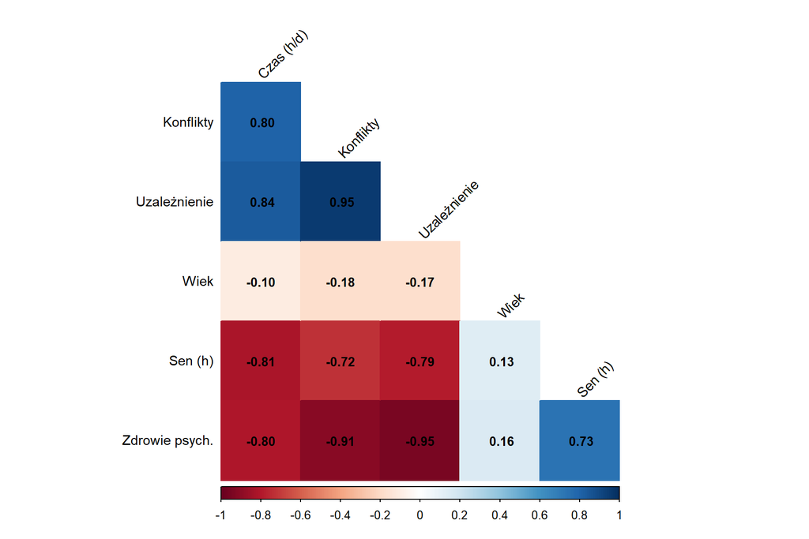

### 4.1 Korelacje: czas w SM vs reszta

Korelacje Spearmana: czas korzystania z SM (h/d) vs pozostałe zmienne (korekta Holm)

| Zmienna | rho | p | p_adj |
| --- | --- | --- | --- |
| Uzależnienie | 0.84 | 0.000 | 0.000 |
| Sen (h/noc) | -0.81 | 0.000 | 0.000 |
| Zdrowie psychiczne | -0.80 | 0.000 | 0.000 |
| Konflikty w SM | 0.80 | 0.000 | 0.000 |
| Wiek | -0.10 | 0.007 | 0.007 |

Najsilniejsze zależności dotyczą obszaru uzależnienia, konfliktów, snu oraz zdrowia psychicznego. Dla czasu w SM otrzymano m.in.:

uzależnienie: rho = 0.84, p_adj = <0.001

konflikty w SM: rho = 0.80, p_adj = <0.001

sen: rho = -0.81, p_adj = <0.001

zdrowie psychiczne: rho = -0.80, p_adj = <0.001

wiek: rho = -0.10, p_adj = 0.007

W praktyce oznacza to, że większy czas w SM współwystępuje z wyższym uzależnieniem i większą liczbą konfliktów, natomiast jest powiązany z krótszym snem oraz niższą oceną zdrowia psychicznego. Zależność wieku z czasem w SM jest słaba.

### 4.2 Wizualizacja korelacji (lollipop)

Aby uniknąć problemu “nakładania punktów” (typowego dla wykresów rozrzutu przy danych dyskretnych) przedstawiono korelacje w formie wykresu lollipop, który jest bardziej czytelny i porównywalny.

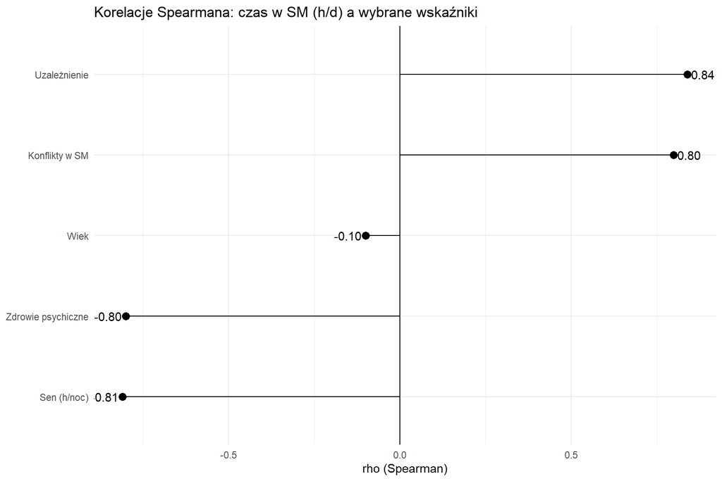

Wykres potwierdza wnioski z tabeli: najsilniejsze dodatnie zależności dotyczą uzależnienia i konfliktów, natomiast najsilniejsze ujemne zależności dotyczą snu i zdrowia psychicznego. Taka forma prezentacji ułatwia szybkie porównanie siły relacji bez błędnych wrażeń wizualnych, które często pojawiają się przy wykresach rozrzutu dla danych dyskretnych.

### 4.3 TOP 10 korelacji

TOP 10 najsilniejszych korelacji (Spearman)

| Zmienna_1 | Zmienna_2 | rho | p |
| --- | --- | --- | --- |
| Uzależnienie | Zdrowie psych. | -0.95 | <0.001 |
| Uzależnienie | Konflikty | 0.95 | <0.001 |
| Konflikty | Zdrowie psych. | -0.91 | <0.001 |
| Uzależnienie | Czas (h/d) | 0.84 | <0.001 |
| Sen (h) | Czas (h/d) | -0.81 | <0.001 |
| Zdrowie psych. | Czas (h/d) | -0.80 | <0.001 |
| Konflikty | Czas (h/d) | 0.80 | <0.001 |
| Uzależnienie | Sen (h) | -0.79 | <0.001 |
| Zdrowie psych. | Sen (h) | 0.73 | <0.001 |
| Konflikty | Sen (h) | -0.72 | <0.001 |

Wyniki analizy korelacji wskazują na istotne statystycznie oraz jednocześnie silne zależności pomiędzy czasem korzystania z mediów społecznościowych a kluczowymi wskaźnikami funkcjonowania badanych osób, w szczególności snem, oceną zdrowia psychicznego, liczbą konfliktów związanych z SM oraz poziomem uzależnienia. Oznacza to, że czas spędzany w SM nie jest zmienną neutralną opisowo, lecz współwystępuje z szeregiem konsekwencji lub cech, które mogą być interpretowane jako potencjalne obszary ryzyka (np. krótszy sen, gorszy dobrostan psychiczny, większa liczba konfliktów) oraz nasilonego problematycznego używania (wysoki wynik uzależnienia). Jednocześnie należy zaznaczyć, że sama korelacja nie umożliwia wnioskowania o kierunku zależności ani o mechanizmie przyczynowym. W praktyce równie możliwe są scenariusze, w których dłuższy czas w SM wpływa na sen i dobrostan, jak i takie, w których gorszy dobrostan lub problemy ze snem sprzyjają większemu korzystaniu z SM, a także scenariusze z udziałem zmiennych pośredniczących i zakłócających.

Z punktu widzenia dalszej części raportu uzyskane zależności stanowią uzasadnienie dla analiz pogłębionych, takich jak porównania grup (np. osoby o niskim i wysokim czasie korzystania), a także modelowanie wielowymiarowe, w którym można jednocześnie uwzględnić kilka predyktorów i ocenić ich niezależny wkład. Warto jednak zachować ostrożność metodologiczną, ponieważ bardzo silne korelacje pomiędzy częścią wskaźników mogą prowadzić do współliniowości w modelach regresyjnych i obniżać stabilność estymacji parametrów. Dlatego w kolejnych etapach analizy zasadne jest sprawdzenie tego zjawiska (np. poprzez diagnostykę VIF) oraz ewentualne ograniczenie liczby silnie skorelowanych zmiennych lub wybór wskaźników reprezentatywnych. Podsumowując, analiza korelacji dostarcza spójnego obrazu współzależności badanych cech i stanowi solidny punkt wyjścia do dalszych wniosków, przy zachowaniu poprawnej interpretacji statystycznej.

## 5. Wykresy

W tej sekcji przedstawiono **analizę wizualną** zależności pomiędzy czasem korzystania z social mediów (`Avg_Daily_Usage_Hours`) a wybranymi wynikami dotyczącymi funkcjonowania studentów (uzależnienie, sen, dobrostan psychiczny, konflikty). Celem jest wstępne rozpoznanie **kierunku i siły związku** oraz sprawdzenie, czy w danych widać trendy, które potem testujemy w części statystycznej.

Wykorzystano porównanie **grup czasu w SM** (np. <=2h, 2–4h, …), pokazane jako **boxploty** z punktami (jitter). Takie podejście jest bardziej czytelne dla zmiennych w skali punktowej 0–10 (uzależnienie, zdrowie psychiczne, konflikty), bo wartości są dyskretne i na wykresach nie powstają „paski” jak przy klasycznym scatter.

Ważne: są to zależności **obserwacyjne**. Nawet jeśli trend jest wyraźny, nie oznacza to jeszcze związku przyczynowego (możliwe zmienne trzecie, np. styl życia, stres, obowiązki).

```r
# Skale punktowe (np. 0-10) są dyskretne/porządkowe.
# Dlatego poniżej porównujemy je w grupach czasu spędzanego w SM.
if ("Avg_Daily_Usage_Hours" %in% names(d)) {
  d <- d %>%
    mutate(
      Usage_Group = cut(
        Avg_Daily_Usage_Hours,
        breaks = c(-Inf, 2, 4, 6, 8, Inf),
        labels = c("<=2 h", "2-4 h", "4-6 h", "6-8 h", ">8 h"),
        right = TRUE
      )
    )
}
```

### 5.1 Czas w SM vs uzależnienie

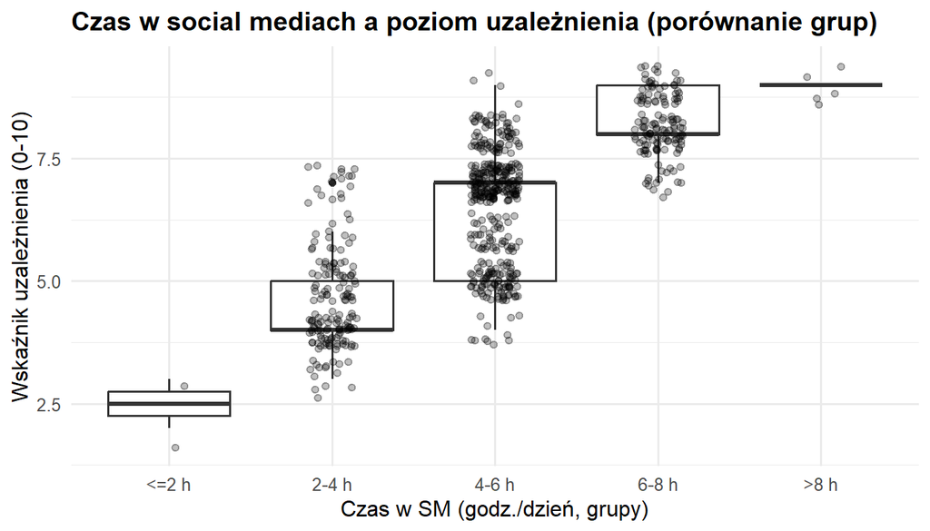

```r
# Czas w SM (w grupach) vs uzależnienie (skala 0-10)

ggplot(d, aes(x = Usage_Group, y = Addicted_Score)) +
  geom_boxplot() +
  geom_jitter(width = 0.15, alpha = 0.25) +
  labs(
    title = "Czas w social mediach a poziom uzależnienia (porównanie grup)",
    x = "Czas w SM (godz./dzień, grupy)",
    y = "Wskaźnik uzależnienia (0-10)"
  )
```

Ten wykres sprawdza, czy osoby spędzające więcej czasu w social mediach mają wyższy wynik `Addicted_Score`.

- Patrzymy głównie na **medianę** (linia w środku pudełka). Jeśli mediana rośnie wraz z grupą czasu, to sugeruje, że dłuższe korzystanie wiąże się z wyższym uzależnieniem.
- Jeżeli pudełka mocno się nakładają, to różnice między grupami są raczej słabe (duży rozrzut indywidualny).

### 5.2 Czas w SM vs sen

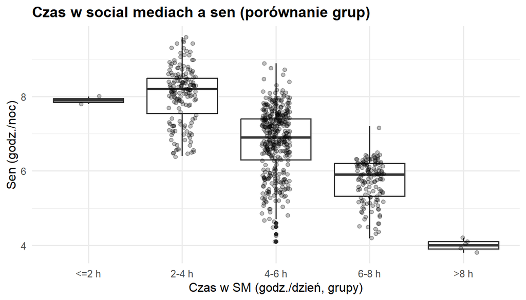

```r
# Czas w SM (w grupach) vs sen

ggplot(d, aes(x = Usage_Group, y = Sleep_Hours_Per_Night)) +
  geom_boxplot() +
  geom_jitter(width = 0.15, alpha = 0.25) +
  labs(
    title = "Czas w social mediach a sen (porównanie grup)",
    x = "Czas w SM (godz./dzień, grupy)",
    y = "Sen (godz./noc)"
  )
```

Ten wykres pokazuje związek między czasem w SM a liczbą godzin snu.

- Jeśli mediany snu są niższe w grupach z większym czasem w SM, to sugeruje, że więcej SM idzie w parze z krótszym snem.
- Rozrzut w grupach pokazuje, że sen zależy też od innych czynników (czas w SM nie tłumaczy wszystkiego).

### 5.3 Czas w SM vs zdrowie psychiczne

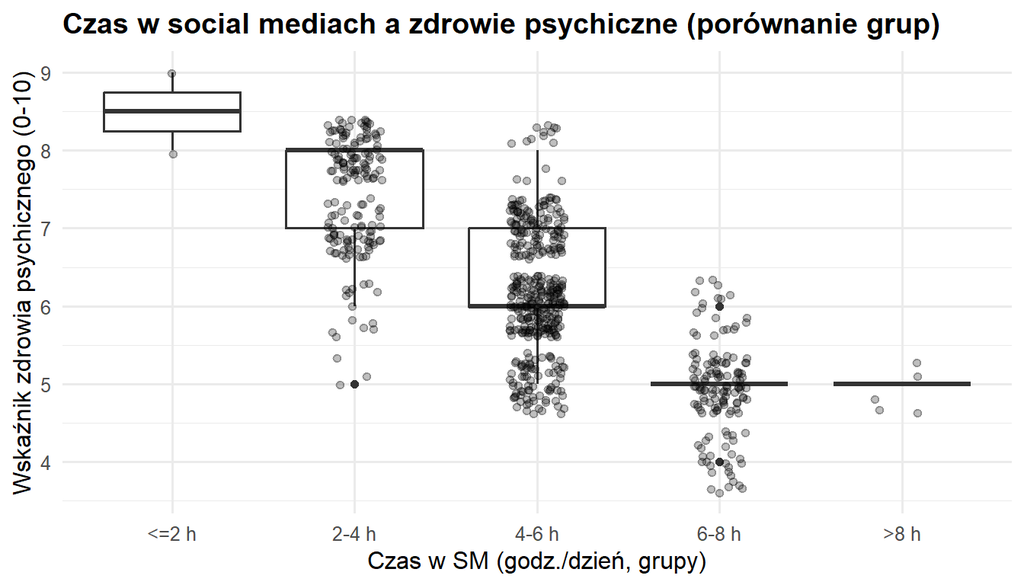

```r
# Czas w SM (w grupach) vs zdrowie psychiczne (skala 0-10)

ggplot(d, aes(x = Usage_Group, y = Mental_Health_Score)) +
  geom_boxplot() +
  geom_jitter(width = 0.15, alpha = 0.25) +
  labs(
    title = "Czas w social mediach a zdrowie psychiczne (porównanie grup)",
    x = "Czas w SM (godz./dzień, grupy)",
    y = "Wskaźnik zdrowia psychicznego (0-10)"
  )
```

Ten wykres sprawdza, czy wraz ze wzrostem czasu korzystania z SM zmienia się `Mental_Health_Score`.

- Jeśli mediany są niższe w grupach z większym czasem w SM, to sugeruje gorszy wynik zdrowia psychicznego przy dłuższym korzystaniu (w tej skali).
- Jeżeli pudełka są podobne w każdej grupie, to wizualnie wygląda to na słabą zależność.

### 5.4 Czas w SM vs konflikty

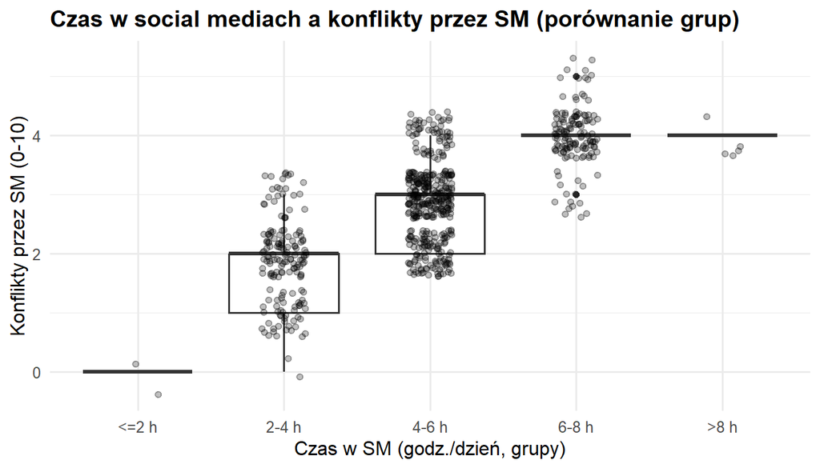

```r
# Czas w SM (w grupach) vs konflikty (skala 0-10)

ggplot(d, aes(x = Usage_Group, y = Conflicts_Over_Social_Media)) +
  geom_boxplot() +
  geom_jitter(width = 0.15, alpha = 0.25) +
  labs(
    title = "Czas w social mediach a konflikty przez SM (porównanie grup)",
    x = "Czas w SM (godz./dzień, grupy)",
    y = "Konflikty przez SM (0-10)"
  )
```

Ten wykres pokazuje, czy częstsze korzystanie z social mediów wiąże się z większą liczbą konfliktów `Conflicts_Over_Social_Media`.

- Jeśli mediany konfliktów rosną wraz z grupą czasu w SM, to sugeruje dodatnią zależność.
- Gdy w każdej grupie jest duży rozrzut, oznacza to, że konflikty zależą też od innych rzeczy (np. styl korzystania, relacje, stres).

### 5.5 Struktura wyboru platform

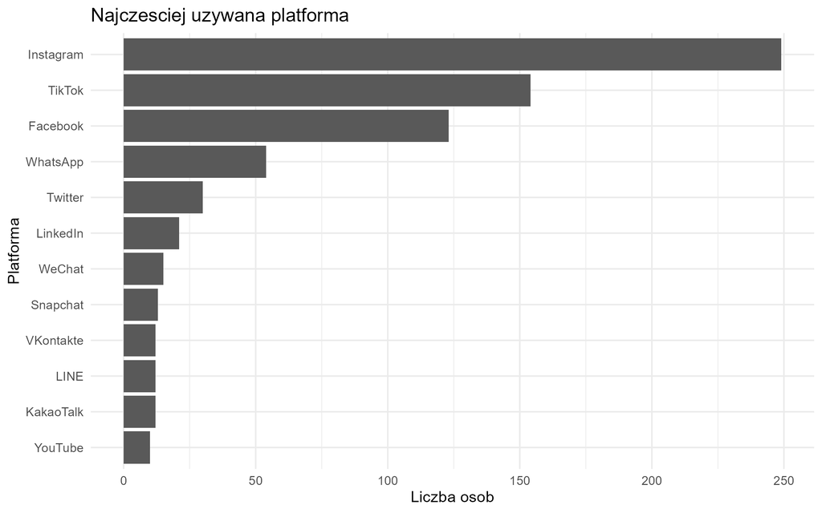

Wykres pokazuje strukturę najczęściej wybieranych platform w próbie. Taka informacja pomaga zrozumieć, gdzie studenci spędzają najwięcej czasu i które kanały mogą być kluczowe przy interpretacji kolejnych zależności. To opis rozkładu w badanej grupie, bez wniosków o przyczynowości.

### 5.6 Rozkład czasu korzystania z social mediów

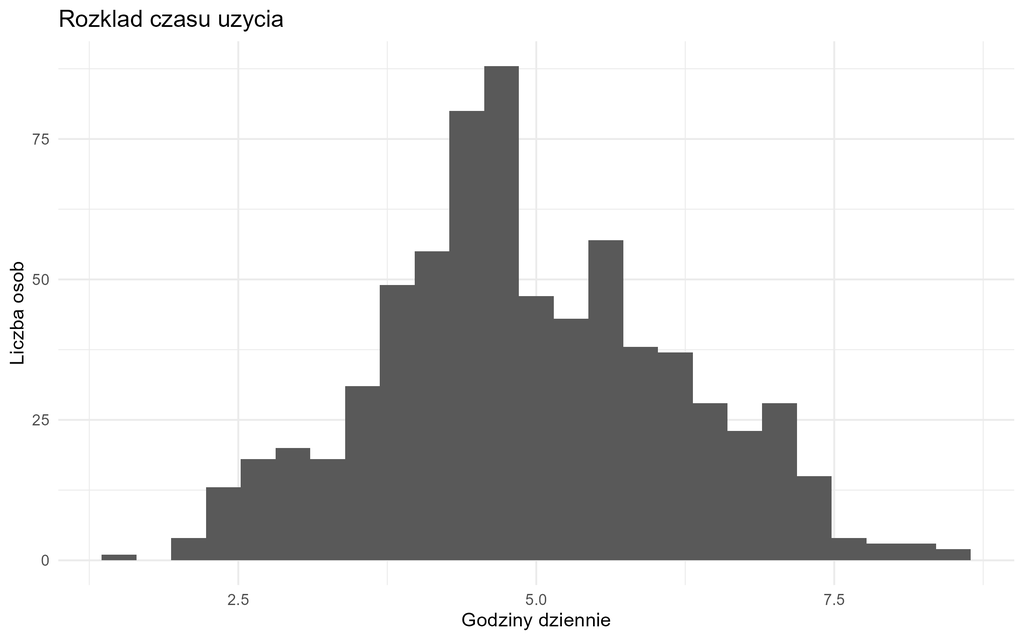

Histogram przedstawia rozkład czasu spędzanego w social mediach. W praktyce oceniamy tu, czy większość osób skupia się przy niższych wartościach (np. kilka godzin), czy występuje ogon po stronie wysokich wartości (pojedyncze osoby z bardzo długim czasem). To ważne przy doborze testów i interpretacji średniej.

### 5.7 Czas w social mediach a poziom uzależnienia

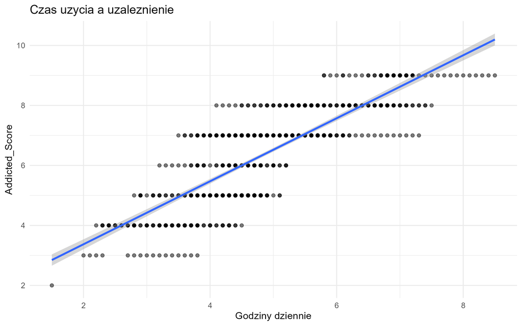

Wykres pokazuje zależność pomiędzy czasem korzystania a wskaźnikiem uzależnienia. Jeśli widoczny jest trend rosnący, sugeruje to dodatni związek: więcej czasu częściej idzie w parze z wyższym wynikiem uzależnienia. To nadal zależność korelacyjna, nie dowód przyczyny.

### 5.8 Sen a poziom uzależnienia

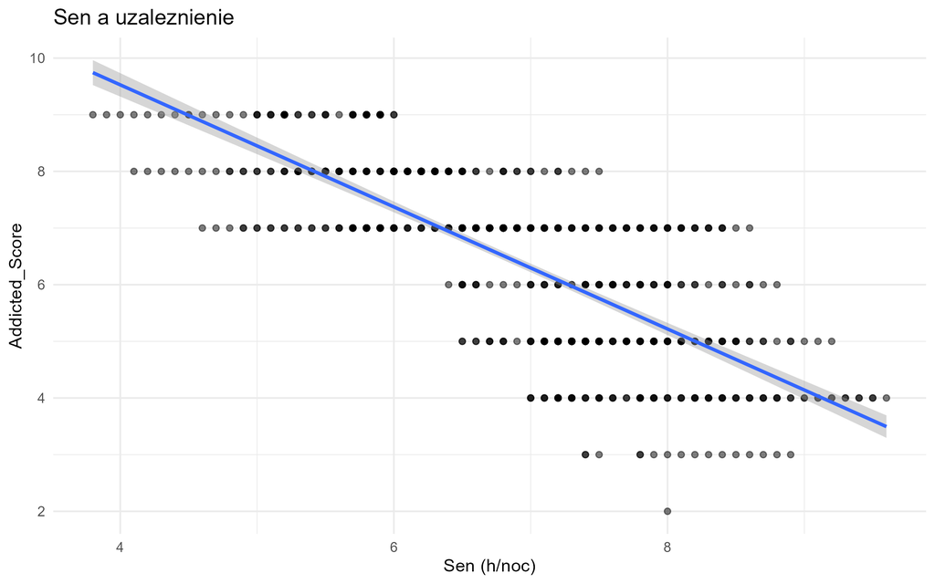

Wykres zestawia długość snu z poziomem uzależnienia. Często w danych tego typu widać, że niższy sen współwystępuje z wyższym uzależnieniem. Interpretujemy to jako współwystępowanie cech w próbie, a nie pewny wpływ jednej zmiennej na drugą.

### 5.9 Czas w social mediach w grupach „Yes/No”

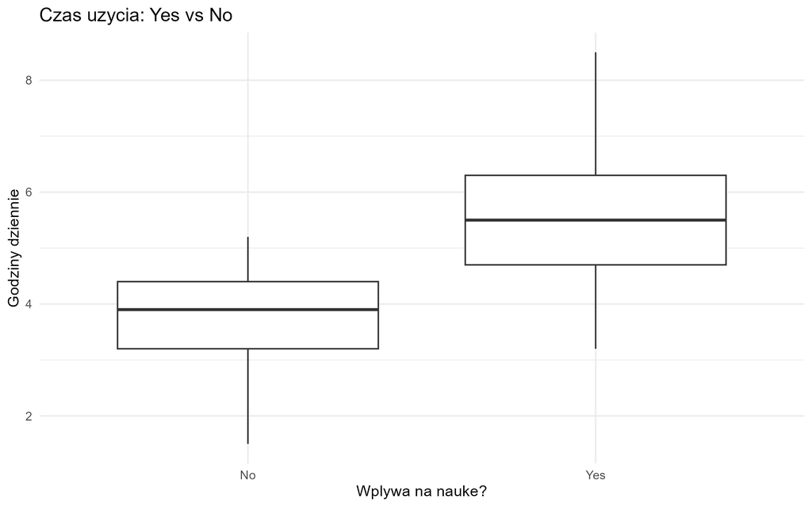

Porównanie pudełkowe pokazuje różnice w czasie korzystania między grupami „Yes/No” (np. deklarowany wpływ na naukę). Patrzymy na medianę, rozrzut i obserwacje odstające. Jeśli rozkłady wyraźnie się rozjeżdżają, to jest to argument za istotną różnicą między grupami.

### 5.10 Rozkład wskaźnika uzależnienia

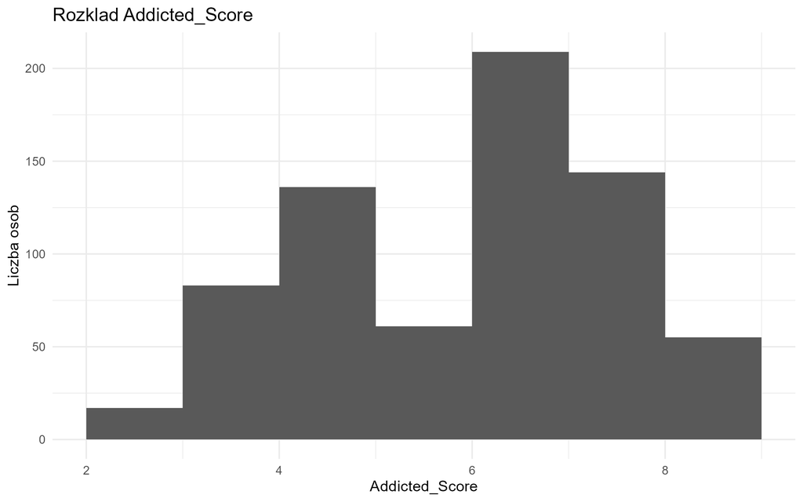

Histogram wskaźnika uzależnienia pokazuje, jak rozkłada się wynik w badanej próbie. Dzięki temu widać, czy większość osób ma wyniki umiarkowane, czy są skupienia przy wysokich wartościach. To pomaga ocenić „profil” próby i potencjalne wartości odstające.

### 5.11 Uzależnienie w grupach „Yes/No”

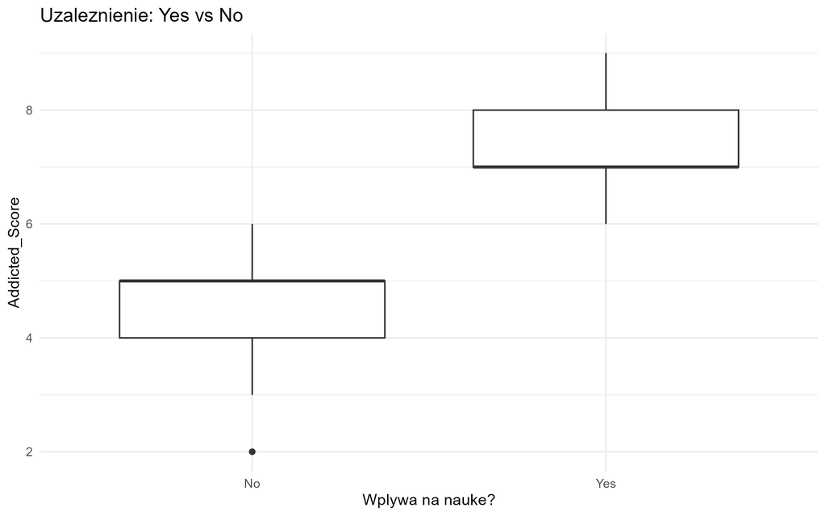

Wykres pudełkowy porównuje poziom uzależnienia w dwóch grupach „Yes/No”. Różnice w medianie i rozrzucie to szybka wizualna informacja o tym, czy deklaracje uczestników idą w parze z innym poziomem uzależnienia. Pełną ocenę wspiera później test statystyczny.

### 5.12 Uzależnienie a najczęściej używana platforma

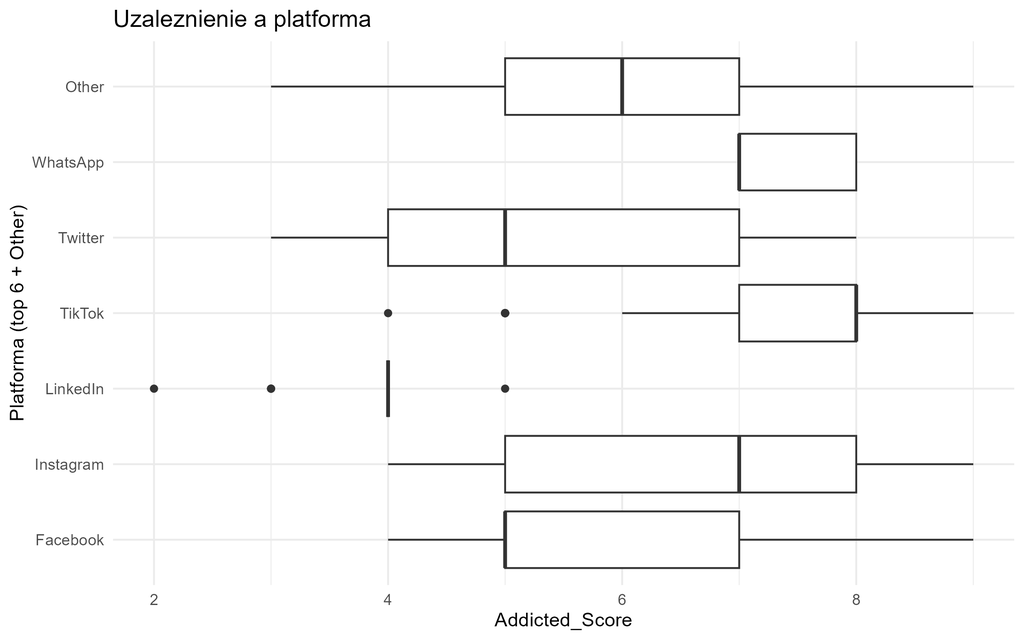

Wykres pokazuje, czy poziom uzależnienia różni się między platformami (np. TikTok, Instagram itd.). To może sugerować, że charakter korzystania jest inny zależnie od aplikacji. Trzeba pamiętać, że grupy mogą mieć różne liczebności, co wpływa na stabilność porównań.

### 5.13 Wiek a uzależnienie

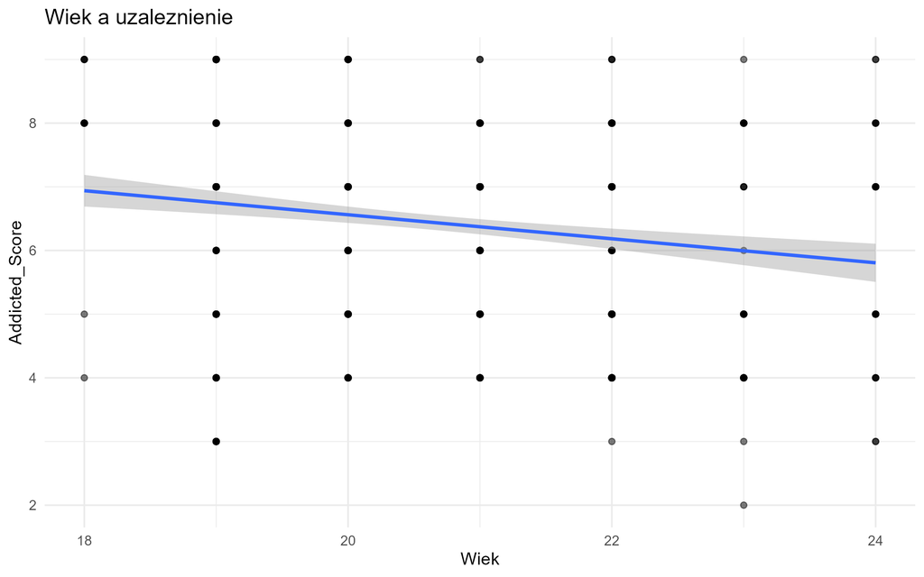

Wykres zestawia wiek z poziomem uzależnienia. W danych studenckich zakres wieku bywa wąski, więc silny trend nie zawsze musi się pojawić. Jeśli zależność jest słaba, to też jest wynik: wiek w tej próbie może nie różnicować uzależnienia w sposób wyraźny.

### 5.14 Diagnostyka modelu liniowego: reszty vs dopasowanie

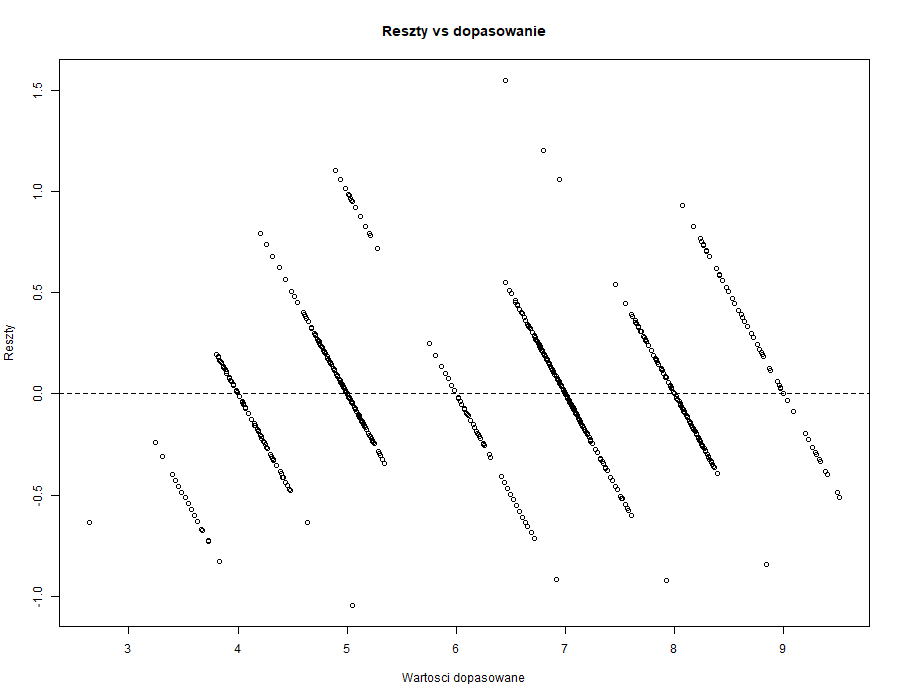

To klasyczny wykres diagnostyczny dla modelu liniowego: reszty w funkcji wartości dopasowanych. Szukamy wzorca (np. „lejka” dla heteroskedastyczności) lub nieliniowości. Jeśli punkty są w miarę losowo rozrzucone wokół zera, założenia modelu są bardziej wiarygodne.

### 5.15 Diagnostyka modelu liniowego: wykres Q–Q

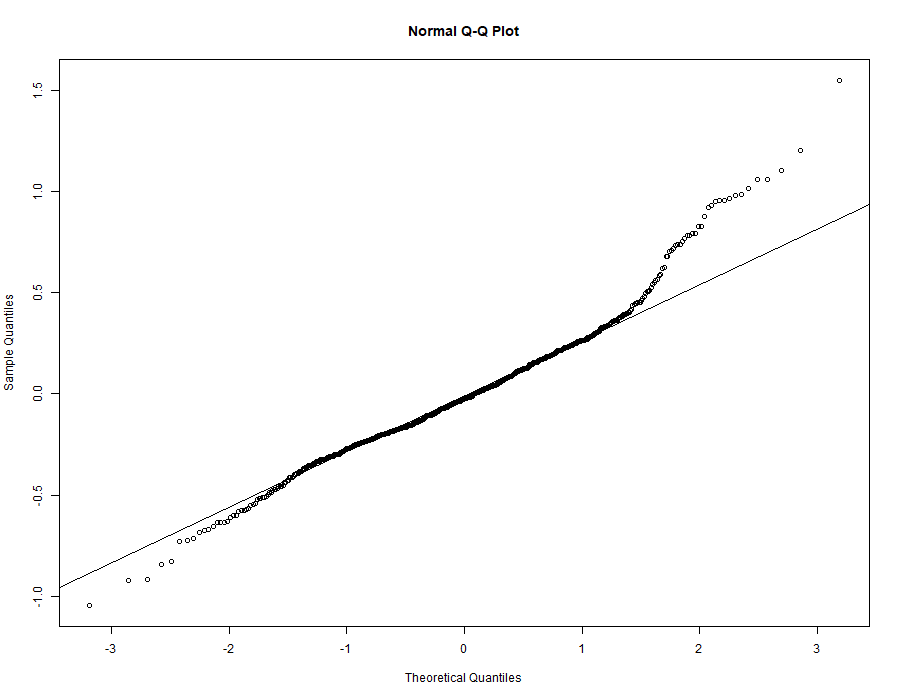

Wykres Q–Q służy do oceny, czy reszty modelu liniowego są zbliżone do rozkładu normalnego. Punkty blisko prostej sugerują zgodność z normalnością, a odchylenia na końcach mogą wskazywać na grube ogony lub obserwacje odstające. To wpływa na interpretację testów w modelu.

### 5.16 Korelacje między zmiennymi (corrplot)

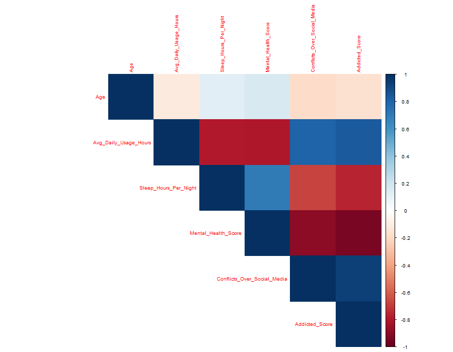

Macierz korelacji pokazuje siłę i kierunek zależności liniowych między zmiennymi. Najbardziej „intensywne” pola wskazują pary o najsilniejszym związku. Taki wykres jest też szybkim sposobem na wychwycenie współliniowości przed modelowaniem.

### 5.17 Krzywa ROC dla modelu logistycznego

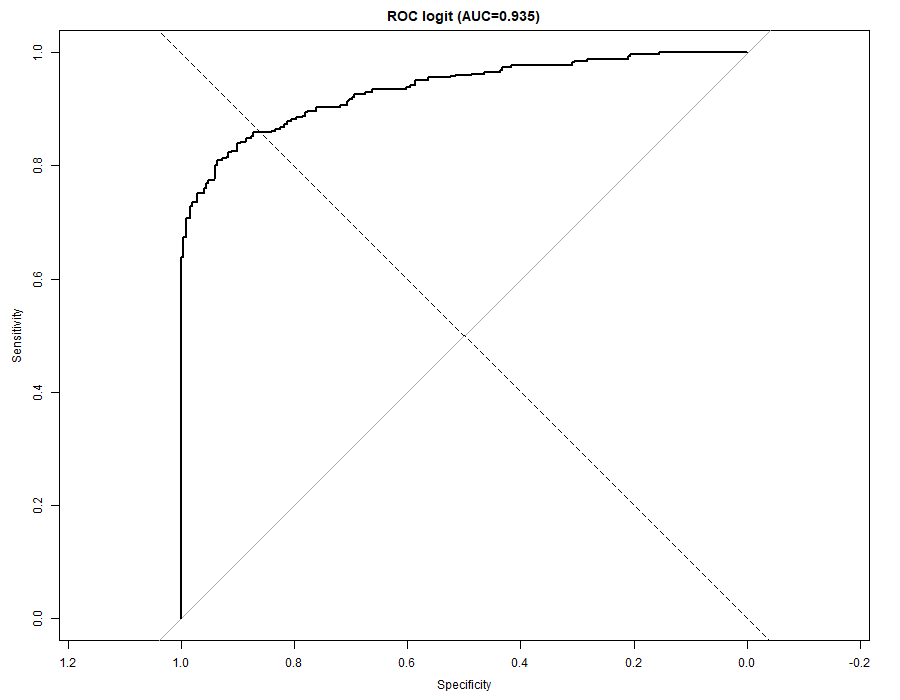

```r
# Porównanie grup Yes vs No

vars_yesno <- c(
  "Avg_Daily_Usage_Hours",
  "Sleep_Hours_Per_Night",
  "Addicted_Score",
  "Mental_Health_Score",
  "Conflicts_Over_Social_Media",
  "Age"
)
vars_yesno <- intersect(vars_yesno, names(d))

res_t <- purrr::map(vars_yesno, ~t.test(reformulate("Affects_Academic_Performance", response = .x), data = d))

names(res_t) <- vars_yesno

# Wyniki (skrót)
purrr::imap(res_t, ~broom::tidy(.x))
```

```
## $Avg_Daily_Usage_Hours
## # A tibble: 1 × 10
##   estimate estimate1 estimate2 statistic  p.value parameter conf.low conf.high
##      <dbl>     <dbl>     <dbl>     <dbl>    <dbl>     <dbl>    <dbl>     <dbl>
## 1    -1.73      3.80      5.54     -25.4 3.23e-99      647.    -1.87     -1.60
## # ℹ 2 more variables: method <chr>, alternative <chr>
##
## $Sleep_Hours_Per_Night
## # A tibble: 1 × 10
##   estimate estimate1 estimate2 statistic  p.value parameter conf.low conf.high
##      <dbl>     <dbl>     <dbl>     <dbl>    <dbl>     <dbl>    <dbl>     <dbl>
## 1     1.47      7.81      6.34      23.3 2.37e-88      662.     1.35      1.59
## # ℹ 2 more variables: method <chr>, alternative <chr>
##
## $Addicted_Score
## # A tibble: 1 × 10
##   estimate estimate1 estimate2 statistic   p.value parameter conf.low conf.high
##      <dbl>     <dbl>     <dbl>     <dbl>     <dbl>     <dbl>    <dbl>     <dbl>
## 1    -2.87      4.60      7.46     -47.8 8.66e-204      582.    -2.98     -2.75
## # ℹ 2 more variables: method <chr>, alternative <chr>
##
## $Mental_Health_Score
## # A tibble: 1 × 10
##   estimate estimate1 estimate2 statistic   p.value parameter conf.low conf.high
##      <dbl>     <dbl>     <dbl>     <dbl>     <dbl>     <dbl>    <dbl>     <dbl>
## 1     1.86      7.42      5.56      40.2 1.43e-180      667.     1.77      1.95
## # ℹ 2 more variables: method <chr>, alternative <chr>
##
## $Conflicts_Over_Social_Media
## # A tibble: 1 × 10
##   estimate estimate1 estimate2 statistic   p.value parameter conf.low conf.high
##      <dbl>     <dbl>     <dbl>     <dbl>     <dbl>     <dbl>    <dbl>     <dbl>
## 1    -1.66      1.78      3.44     -42.5 1.91e-186      624.    -1.74     -1.59
## # ℹ 2 more variables: method <chr>, alternative <chr>
##
## $Age
## # A tibble: 1 × 10
##   estimate estimate1 estimate2 statistic  p.value parameter conf.low conf.high
##      <dbl>     <dbl>     <dbl>     <dbl>    <dbl>     <dbl>    <dbl>     <dbl>
## 1    0.400      20.9      20.5      3.59 0.000357      488.    0.181     0.619
## # ℹ 2 more variables: method <chr>, alternative <chr>
```

W tym chuncku wykonujemy serię **testów t-Studenta** porównujących dwie grupy studentów:

- grupa **No**: osoby, które deklarują, że social media nie wpływają na wyniki w nauce,
- grupa **Yes**: osoby, które deklarują, że social media wpływają na wyniki w nauce.

Cała logika jest taka, żeby nie robić testu „ręcznie” dla każdej zmiennej osobno, tylko zrobić to automatycznie w pętli (tutaj pętla jest zrobiona przez `purrr::map`).

Co dokładnie dzieje się linijka po linijce:

1. `vars_yesno <- c(...)` tworzy listę zmiennych liczbowych, które chcemy porównać między grupami. Są tu:
   - `Avg_Daily_Usage_Hours` (czas w social mediach),
   - `Sleep_Hours_Per_Night` (sen),
   - `Addicted_Score` (uzależnienie),
   - `Mental_Health_Score` (zdrowie psychiczne),
   - `Conflicts_Over_Social_Media` (konflikty),
   - `Age` (wiek).
2. `vars_yesno <- intersect(vars_yesno, names(d))` zostawia tylko te zmienne, które faktycznie istnieją w danych `d`. To jest zabezpieczenie, żeby raport nie wywalił błędu, jeśli jakaś nazwa byłaby inna.
3. `purrr::map(vars_yesno, ~t.test(...))` uruchamia test t dla każdej zmiennej z listy.
   - `reformulate("Affects_Academic_Performance", response = .x)` buduje formułę typu: `ZMIENNA ~ Affects_Academic_Performance` czyli np. `Sleep_Hours_Per_Night ~ Affects_Academic_Performance`.
   - `t.test(..., data = d)` wykonuje test t-Studenta porównujący średnie dwóch grup (Yes i No). Domyślnie w R jest to wersja Welcha, która nie zakłada równości wariancji.
4. `names(res_t) <- vars_yesno` nadaje wynikom nazwy, żeby łatwiej było się w nich odnaleźć (wynik dla snu będzie pod nazwą `Sleep_Hours_Per_Night` itd.).
5. `purrr::imap(res_t, ~broom::tidy(.x))` konwertuje każdy wynik testu t do „czystej” tabelki.

W tabelkach zwykle pojawiają się m.in.:

- `estimate`: różnica średnich (średnia w jednej grupie minus średnia w drugiej),
- `statistic`: wartość statystyki t,
- `p.value`: wartość p (czy różnica jest istotna statystycznie),
- `conf.low` i `conf.high`: przedział ufności dla różnicy średnich,
- `parameter`: stopnie swobody (df).

Jak to interpretować:

- jeśli `p.value` jest małe (np. < 0.05), to średnie w grupach Yes i No różnią się istotnie statystycznie,
- znak `estimate` mówi kierunek różnicy (czy grupa Yes ma średnio więcej czy mniej),
- przedział ufności pokazuje, w jakim zakresie może być „prawdziwa” różnica średnich.

To porównanie jest ważne, bo pozwala sprawdzić, czy deklaracja „wpływa na naukę” idzie w parze z realnymi różnicami w zachowaniach i wskaźnikach (czas w SM, sen, uzależnienie, dobrostan, konflikty).

### 6.1 Średnie w grupach Yes/No

```r
vars <- c(
  "Avg_Daily_Usage_Hours",
  "Sleep_Hours_Per_Night",
  "Addicted_Score",
  "Mental_Health_Score",
  "Conflicts_Over_Social_Media",
  "Age"
)
vars <- intersect(vars, names(d))

means_long <- d %>%
  select(Affects_Academic_Performance, all_of(vars)) %>%
  pivot_longer(
    cols = -Affects_Academic_Performance,
    names_to = "zmienna",
    values_to = "wartosc"
  ) %>%
  group_by(Affects_Academic_Performance, zmienna) %>%
  summarise(
    n = sum(!is.na(wartosc)),
    srednia = mean(wartosc, na.rm = TRUE),
    sd = sd(wartosc, na.rm = TRUE),
    .groups = "drop"
  ) %>%
  mutate(
    wynik = sprintf("%.2f (%.2f)", srednia, sd)
  ) %>%
  select(Affects_Academic_Performance, zmienna, n, wynik)

knitr::kable(
  means_long,
  caption = "Średnie (SD) w grupach Affects_Academic_Performance (No/Yes)",
  align = "l"
)
```

Średnie (SD) w grupach Affects_Academic_Performance (No/Yes)

| Affects_Academic_Performance | zmienna | n | wynik |
| --- | --- | --- | --- |
| No | Addicted_Score | 252 | 4.60 (0.72) |
| No | Age | 252 | 20.92 (1.45) |
| No | Avg_Daily_Usage_Hours | 252 | 3.80 (0.77) |
| No | Conflicts_Over_Social_Media | 252 | 1.78 (0.45) |
| No | Mental_Health_Score | 252 | 7.42 (0.50) |
| No | Sleep_Hours_Per_Night | 252 | 7.81 (0.69) |
| Yes | Addicted_Score | 453 | 7.46 (0.83) |
| Yes | Age | 453 | 20.52 (1.35) |
| Yes | Avg_Daily_Usage_Hours | 453 | 5.54 (1.03) |
| Yes | Conflicts_Over_Social_Media | 453 | 3.44 (0.57) |
| Yes | Mental_Health_Score | 453 | 5.56 (0.72) |
| Yes | Sleep_Hours_Per_Night | 453 | 6.34 (0.97) |

### 6.2 Testy nieparametryczne i wielkość efektu

W testach t zakładamy (w uproszczeniu), że porównujemy średnie i że rozkłady nie są „totalnie dziwne”.  
Dlatego dokładamy też wersję **nieparametryczną** (Wilcoxona), która jest bardziej odporna na odstające wartości.

Dodatkowo pokazuję **Cohen’s d** (wielkość efektu), żeby nie kończyć tylko na p-value.

Yes vs No: różnica średnich (Yes-No), p-value (t i Wilcox) oraz Cohen d

| zmienna | diff_mean_yes_minus_no | t_p | wilcox_p | cohen_d |
| --- | --- | --- | --- | --- |
| Avg_Daily_Usage_Hours | 1.7343 | 0.0000 | 0.0000 | 1.8378 |
| Sleep_Hours_Per_Night | -1.4694 | 0.0000 | 0.0000 | -1.6699 |
| Addicted_Score | 2.8661 | 0.0000 | 0.0000 | 3.6094 |
| Mental_Health_Score | -1.8639 | 0.0000 | 0.0000 | -2.8669 |
| Conflicts_Over_Social_Media | 1.6620 | 0.0000 | 0.0000 | 3.1252 |
| Age | -0.4001 | 0.0004 | 0.0004 | -0.2885 |

Jak czytać tabelę: - `diff_mean_yes_minus_no` > 0: grupa **Yes** ma średnio więcej (np. więcej godzin, wyższy Addicted_Score). - `cohen_d`: im większa wartość bezwzględna, tym mocniejszy efekt (w praktyce często: ok. 0.2 mały, 0.5 średni, 0.8 duży).

### 6.3 Zależności dla zmiennych kategorycznych (Chi-kwadrat)

Tu sprawdzamy, czy odpowiedź **Yes/No** w `Affects_Academic_Performance` jest powiązana np. z płcią, poziomem studiów, platformą itd.  
Oprócz p-value pokazujemy **V Cramera** jako miarę siły związku.

```r
cramers_v <- function(tab) {
  cs <- suppressWarnings(chisq.test(tab, correct = FALSE))
  chi2 <- as.numeric(cs$statistic)
  n <- sum(tab)
  r <- nrow(tab); k <- ncol(tab)
  sqrt(chi2 / (n * (min(r - 1, k - 1))))
}

cat_tests <- c("Gender","Academic_Level","Most_Used_Platform","Relationship_Status")
cat_tests <- intersect(cat_tests, names(d))

if ("Affects_Academic_Performance" %in% names(d) && length(cat_tests) > 0) {
  chi_tbl <- purrr::map_dfr(cat_tests, function(v) {
    tab <- table(d$Affects_Academic_Performance, d[[v]])
    cs <- suppressWarnings(chisq.test(tab))
    tibble(
      zmienna = v,
      chi2_p = cs$p.value,
      cramers_v = cramers_v(tab)
    )
  }) %>% mutate(across(where(is.numeric), ~round(.x, 4)))

  chi_tbl %>%
    knitr::kable(
      digits = 4,
      caption = "Chi-kwadrat: Affects_Academic_Performance vs zmienne kategoryczne (plus V Cramera)"
    )
} else {
  cat("Brak Affects_Academic_Performance lub brak zmiennych kategorycznych do testu chi^2.")
}
```

Chi-kwadrat: Affects_Academic_Performance vs zmienne kategoryczne (plus V Cramera)

| zmienna | chi2_p | cramers_v |
| --- | --- | --- |
| Gender | 0.5631 | 0.0247 |
| Academic_Level | 0.0045 | 0.1237 |
| Most_Used_Platform | 0.0000 | 0.6077 |
| Relationship_Status | 0.0000 | 0.1795 |

Interpretacja wyników:

- `chi2_p` (p-value) mówi, czy w próbie widać istotną zależność między **Yes/No** a daną zmienną kategoryczną.
- `cramers_v` mówi o **sile związku**: wartości bliskie 0 to słaby związek, większe wartości to mocniejszy związek.

W praktyce może być tak, że p-value wyjdzie małe (bo próba jest duża), ale `V Cramera` będzie małe, czyli zależność istnieje, ale jest raczej słaba.

### 6.4 Różnice między wieloma grupami (Kruskal-Wallis)

Test t jest dla dwóch grup. Jeśli mamy więcej grup (np. różne platformy), to robimy **Kruskal-Wallis**.  
Potem (gdy wyjdzie istotnie) można dorzucić porównania parami (Wilcoxon + poprawka BH).

```r
if ("Most_Used_Platform" %in% names(d) && "Addicted_Score" %in% names(d)) {
  d_pl <- d %>% mutate(Most_Used_Platform = fct_lump_n(Most_Used_Platform, n = 6, other_level = "Other"))
  kw1 <- kruskal.test(Addicted_Score ~ Most_Used_Platform, data = d_pl)
  kw1

  pw1 <- suppressWarnings(pairwise.wilcox.test(
    d_pl$Addicted_Score, d_pl$Most_Used_Platform,
    p.adjust.method = "BH", exact = FALSE
  ))
  pw1
} else {
  cat("Brak Most_Used_Platform lub Addicted_Score.")
}
```

```
##
##  Pairwise comparisons using Wilcoxon rank sum test with continuity correction
##
## data:  d_pl$Addicted_Score and d_pl$Most_Used_Platform
##
##           Facebook Instagram LinkedIn TikTok  Twitter WhatsApp
## Instagram 9.7e-07  -         -        -       -       -
## LinkedIn  2.5e-09  1.5e-11   -        -       -       -
## TikTok    < 2e-16  9.9e-09   1.6e-13  -       -       -
## Twitter   0.4704   0.0015    2.2e-05  1.1e-08 -       -
## WhatsApp  2.7e-12  2.2e-05   5.7e-12  0.7225  1.3e-07 -
## Other     0.5856   4.3e-05   1.7e-06  1.9e-15 0.5707  2.5e-12
##
## P value adjustment method: BH
```

```r
if ("Academic_Level" %in% names(d) && "Addicted_Score" %in% names(d)) {
  kw2 <- kruskal.test(Addicted_Score ~ Academic_Level, data = d)
  kw2

  pw2 <- suppressWarnings(pairwise.wilcox.test(
    d$Addicted_Score, d$Academic_Level,
    p.adjust.method = "BH", exact = FALSE
  ))
  pw2
} else {
  cat("Brak Academic_Level lub Addicted_Score.")
}
```

```
##
##  Pairwise comparisons using Wilcoxon rank sum test with continuity correction
##
## data:  d$Addicted_Score and d$Academic_Level
##
##               Graduate High School
## High School   2.7e-10  -
## Undergraduate 0.035    5.2e-07
##
## P value adjustment method: BH
```

To podejście jest sensowne, gdy grup jest więcej niż 2 i nie chcemy zakładać normalności rozkładów.

## 7. Modele

W tej sekcji przechodzimy od prostych porównań (korelacje, wykresy, testy t) do **modelowania statystycznego**, czyli próbujemy opisać zależności „bardziej formalnie” i jednocześnie uwzględnić kilka czynników naraz.

Dlaczego to jest potrzebne?

- Korelacje i wykresy pokazują ogólny kierunek zależności, ale nie rozdzielają wpływu kilku zmiennych naraz.
- Testy t porównują tylko dwie grupy (Yes vs No) osobno dla każdej zmiennej, bez kontroli innych cech.

Modele pozwalają:

- ocenić, czy np. czas w SM dalej ma związek z wynikiem, gdy „trzymamy stałe” inne zmienne (sen, zdrowie psychiczne, konflikty, płeć itp.),
- uzyskać liczbową miarę efektu (współczynnik w modelu liniowym lub OR w modelu logistycznym),
- sprawdzić istotność statystyczną i niepewność (p-value i przedziały ufności).

W raporcie używamy dwóch modeli:

1. **Model liniowy (lm)**: gdy zmienna wynikowa jest liczbowa i ciągła. Tutaj przewidujemy `Addicted_Score`.
2. **Model logistyczny (glm binomial)**: gdy zmienna wynikowa jest binarna (Yes/No). Tutaj przewidujemy prawdopodobieństwo odpowiedzi „Yes” w `Affects_Academic_Performance`.

### 7.1 Model liniowy

```r
# Model liniowy: co wpływa na Addicted_Score

# platformy grupujemy: top 6 + Other

d_m1 <- d %>%
  mutate(Most_Used_Platform = forcats::fct_lump_n(Most_Used_Platform, n = 6, other_level = "Other"))

m1 <- lm(
  Addicted_Score ~ Avg_Daily_Usage_Hours + Sleep_Hours_Per_Night + Mental_Health_Score +
    Conflicts_Over_Social_Media + Affects_Academic_Performance + Gender + Most_Used_Platform,
  data = d_m1
)

summary(m1)
```

```
##
## Call:
## lm(formula = Addicted_Score ~ Avg_Daily_Usage_Hours + Sleep_Hours_Per_Night +
##     Mental_Health_Score + Conflicts_Over_Social_Media + Affects_Academic_Performance +
##     Gender + Most_Used_Platform, data = d_m1)
##
## Residuals:
##     Min      1Q  Median      3Q     Max
## -1.0460 -0.1973 -0.0222  0.1730  1.5510
##
## Coefficients:
##                                 Estimate Std. Error t value Pr(>|t|)
## (Intercept)                      9.09311    0.33566  27.091  < 2e-16 ***
## Avg_Daily_Usage_Hours            0.11301    0.02330   4.850 1.53e-06 ***
## Sleep_Hours_Per_Night           -0.17312    0.02003  -8.645  < 2e-16 ***
## Mental_Health_Score             -0.58158    0.02817 -20.644  < 2e-16 ***
## Conflicts_Over_Social_Media      0.41796    0.03551  11.771  < 2e-16 ***
## Affects_Academic_PerformanceYes  0.58716    0.05212  11.265  < 2e-16 ***
## GenderMale                       0.06371    0.02724   2.339 0.019642 *
## Most_Used_PlatformInstagram      0.03388    0.04088   0.829 0.407466
## Most_Used_PlatformLinkedIn      -0.07194    0.08862  -0.812 0.417183
## Most_Used_PlatformTikTok         0.15412    0.04571   3.372 0.000789 ***
## Most_Used_PlatformTwitter       -0.20112    0.06767  -2.972 0.003062 **
## Most_Used_PlatformWhatsApp      -0.21077    0.06046  -3.486 0.000521 ***
## Most_Used_PlatformOther         -0.19451    0.05030  -3.867 0.000121 ***
## ---
## Signif. codes:  0 '***' 0.001 '**' 0.01 '*' 0.05 '.' 0.1 ' ' 1
##
## Residual standard error: 0.3261 on 692 degrees of freedom
## Multiple R-squared:  0.9585, Adjusted R-squared:  0.9578
## F-statistic:  1332 on 12 and 692 DF,  p-value: < 2.2e-16
```

```r
car::vif(m1)
```

```
##                                  GVIF Df GVIF^(1/(2*Df))
## Avg_Daily_Usage_Hours        5.684387  1        2.384195
## Sleep_Hours_Per_Night        3.372006  1        1.836302
## Mental_Health_Score          6.417863  1        2.533350
## Conflicts_Over_Social_Media  7.661222  1        2.767891
## Affects_Academic_Performance 4.137715  1        2.034138
## Gender                       1.230406  1        1.109237
## Most_Used_Platform           2.906094  6        1.092972
```

W tym chuncku budujemy **model liniowy**, gdzie zmienną objaśnianą jest `Addicted_Score` (poziom uzależnienia), a zmiennymi objaśniającymi są m.in. czas w SM, sen, zdrowie psychiczne, konflikty oraz cechy jakościowe.

1. `d_m1 <- d %>% mutate(...)` tworzy kopię danych do modelu. Jedyna zmiana dotyczy platformy:
   - `forcats::fct_lump_n(Most_Used_Platform, n = 6, other_level = "Other")` zostawia 6 najczęstszych platform, a pozostałe łączy do kategorii `Other`.
   - To ułatwia estymację i interpretację, bo nie tworzymy w modelu kilkunastu bardzo rzadkich kategorii (które dawałyby niestabilne współczynniki).
2. `m1 <- lm(...)` dopasowuje klasyczną regresję liniową metodą najmniejszych kwadratów (OLS).
   - Wzór ma postać: `Addicted_Score ~ ...`.
   - Współczynnik przy `Avg_Daily_Usage_Hours` mówi, jak średnio zmienia się `Addicted_Score`, gdy czas w SM rośnie o 1 godzinę, **przy założeniu**, że pozostałe zmienne w modelu są stałe.
   - Analogicznie współczynniki przy `Sleep_Hours_Per_Night`, `Mental_Health_Score` i `Conflicts_Over_Social_Media` opisują ich „częściowy” związek z uzależnieniem.
   - Zmienne jakościowe (`Affects_Academic_Performance`, `Gender`, `Most_Used_Platform`) są kodowane jako zestaw zmiennych zero-jedynkowych (R robi to automatycznie dla factorów). Współczynniki interpretujemy jako różnice względem kategorii bazowej.
3. `summary(m1)` wyświetla podsumowanie modelu:
   - oszacowane współczynniki (Estimate),
   - błędy standardowe (Std. Error),
   - statystyki t i p-value (czy efekt jest istotny statystycznie),
   - dopasowanie modelu (R-squared, Adjusted R-squared) i test ogólny (F-statistic).
4. `car::vif(m1)` liczy wskaźniki VIF (Variance Inflation Factor), czyli sprawdza **współliniowość** predyktorów.
   - Gdy VIF jest wysokie, to znaczy, że zmienne objaśniające są mocno ze sobą skorelowane, a wtedy współczynniki mogą być mniej stabilne.
   - W praktyce często przyjmuje się, że wartości około 1–5 są zwykle ok, a dużo wyższe mogą być problemem.

Ten model traktujemy jako uzupełnienie analizy: pokazuje, czy obserwowane zależności (z wykresów i korelacji) utrzymują się, gdy uwzględniamy kilka czynników naraz.

### 7.2 Model logistyczny

```r
# Model logistyczny: co zwiększa szansę, że ktoś odpowie "Yes" (wpływa na naukę)

m_logit <- glm(
  Affects_Academic_Performance ~ Avg_Daily_Usage_Hours + Sleep_Hours_Per_Night + Age + Gender + Academic_Level,
  data = d,
  family = binomial()
)

# OR = iloraz szans
or_tbl <- broom::tidy(m_logit, exponentiate = TRUE, conf.int = TRUE) %>%
  transmute(
    term = term,
    OR = estimate,
    OR_low = conf.low,
    OR_high = conf.high,
    p.value = p.value
  )

or_tbl
```

| term | OR | OR_low | OR_high | p.value |
| --- | --- | --- | --- | --- |
| (Intercept) | 1.399843e+09 | 1.428492e+05 | 1.997748e+13 | 1.020313e-05 |
| Avg_Daily_Usage_Hours | 5.843213e+00 | 3.777882e+00 | 9.494452e+00 | 5.080263e-14 |
| Sleep_Hours_Per_Night | 3.318344e-01 | 2.092667e-01 | 5.109335e-01 | 1.261734e-06 |
| Age | 3.958646e-01 | 2.809502e-01 | 5.490424e-01 | 5.429943e-08 |
| GenderMale | 7.540059e-01 | 3.974281e-01 | 1.425938e+00 | 3.849461e-01 |
| Academic_LevelHigh School | 2.218356e-02 | 2.083089e-03 | 3.418323e-01 | 2.885049e-03 |
| Academic_LevelUndergraduate | 1.016548e-01 | 3.601404e-02 | 2.732217e-01 | 9.203440e-06 |

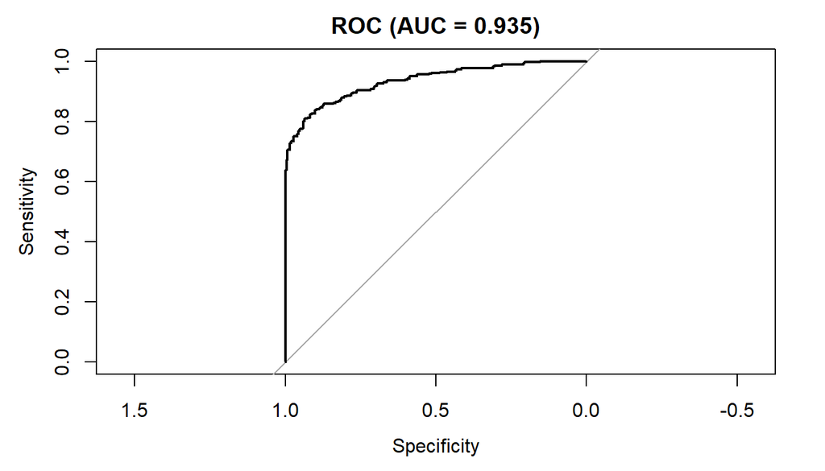

```r
# ROC + AUC
pr <- predict(m_logit, type = "response")
roc_obj <- pROC::roc(d$Affects_Academic_Performance, pr, levels = c("No", "Yes"), direction = "<")
auc_val <- as.numeric(pROC::auc(roc_obj))

# OR-y do tekstu (dla 2 najważniejszych zmiennych)
or_usage <- or_tbl$OR[or_tbl$term == "Avg_Daily_Usage_Hours"][1]
or_sleep <- or_tbl$OR[or_tbl$term == "Sleep_Hours_Per_Night"][1]

plot(roc_obj, main = paste0("ROC (AUC = ", round(auc_val, 3), ")"))
```

W tym chuncku budujemy **model logistyczny**, czyli model dla zmiennej wynikowej typu **Yes/No**. Celem jest oszacowanie, które czynniki zwiększają (lub zmniejszają) prawdopodobieństwo, że student odpowie **“Yes”** w `Affects_Academic_Performance` (czyli że social media wpływają na wyniki w nauce).

Co tu się dzieje po kolei:

1. `m_logit <- glm(..., family = binomial())` dopasowuje regresję logistyczną.
   - W modelu zmienną objaśnianą jest `Affects_Academic_Performance`.
   - Predyktory to: `Avg_Daily_Usage_Hours`, `Sleep_Hours_Per_Night`, `Age`, `Gender`, `Academic_Level`.
   - `family = binomial()` mówi R, że to jest model dla zmiennej binarnej. W praktyce modeluje on **logarytm ilorazu szans** (log-odds) odpowiedzi “Yes”.
2. Tabela OR (ilorazy szans):
   - `broom::tidy(m_logit, exponentiate = TRUE, conf.int = TRUE)` pobiera współczynniki modelu i od razu je “odlogarytmowuje” (`exponentiate = TRUE`).
   - Dzięki temu zamiast współczynników w log-odds dostajemy **OR** (odds ratio, iloraz szans).
   - `conf.int = TRUE` dodaje przedziały ufności dla OR.
   - `transmute(...)` wybiera tylko te kolumny, które są najbardziej czytelne w raporcie: nazwa zmiennej (`term`), OR, dolna i górna granica przedziału ufności oraz p-value.
   - `or_tbl` wyświetla gotową tabelę.

   Jak czytać OR:
   - **OR > 1**: wzrost zmiennej zwiększa szanse odpowiedzi “Yes”.
   - **OR < 1**: wzrost zmiennej zmniejsza szanse odpowiedzi “Yes”.
   - Przykład: OR = 1.20 dla czasu w SM oznacza, że +1 godzina dziennie zwiększa szanse odpowiedzi “Yes” o ok. 20% (przy stałych pozostałych zmiennych).
3. Ocena jakości predykcji (ROC i AUC):
   - `predict(m_logit, type = "response")` liczy przewidywane prawdopodobieństwa odpowiedzi “Yes” dla każdej osoby (liczby od 0 do 1).
   - `pROC::roc(...)` tworzy krzywą ROC, czyli porównuje czułość i swoistość dla różnych progów klasyfikacji.
   - `auc(roc_obj)` liczy AUC (pole pod krzywą). AUC bliskie 0.5 oznacza brak zdolności rozróżniania, a im bliżej 1.0, tym lepsza klasyfikacja.
   - `plot(roc_obj, ...)` rysuje krzywą ROC. Opcjonalnie można dodać linię odniesienia `abline(a=0,b=1,lty=2)`, która pokazuje wynik „losowy” (punkt odniesienia).

Ten chunk jest więc podsumowaniem w formie modelu: pokazuje, które czynniki są statystycznie istotne w przewidywaniu odpowiedzi “Yes” oraz jak dobrze model ogólnie rozróżnia osoby z grupy Yes i No.

## 8. Wnioski

Na podstawie statystyk opisowych, korelacji, wykresów oraz testów porównujących grupy (Yes/No) można sformułować następujące wnioski:

Wyniki należy interpretować jako **zależności obserwacyjne** w badanej próbie. Raport nie rozstrzyga, czy social media *powodują* zmiany w śnie, dobrostanie psychicznym lub funkcjonowaniu w nauce.

Z perspektywy praktycznej wyniki sugerują, że działania ukierunkowane na **higienę snu** oraz **ograniczanie czasu spędzanego w social mediach** mogą być istotnym elementem profilaktyki (szczególnie w grupie osób deklarujących wpływ na naukę). Jednocześnie, ze względu na ograniczenia danych (samoopis i brak pomiaru w czasie), rekomendacje należy traktować jako wstępne i wymagające potwierdzenia w badaniach o silniejszym schemacie (np. panelowych).

## 9. Ograniczenia

Ograniczenia analizy wynikają głównie z charakteru danych oraz z przyjętych uproszczeń analitycznych. Poniższe punkty są kluczowe dla poprawnej interpretacji wyników.

1. **Charakter obserwacyjny (przekrojowy)**: dane pochodzą z jednego pomiaru, więc nie da się wnioskować o kierunku zależności ani o przyczynowości (korelacja ≠ przyczyna). Przykładowo: wyższy czas w SM może wiązać się z gorszym snem, ale równie dobrze gorszy sen może sprzyjać dłuższemu korzystaniu z telefonu.
2. **Samoopis i błąd deklaracji**: czas korzystania, sen oraz ocena wpływu na naukę są deklarowane przez respondentów. Może to powodować:
   - błąd pamięci (niedokładne odtworzenie czasu),
   - błąd społecznej aprobaty (zaniżanie lub zawyżanie odpowiedzi),
   - różne rozumienie pytań przez respondentów. W efekcie oszacowane zależności mogą być osłabione lub przeszacowane.
3. **Brak informacji o doborze próby**: bez opisu sposobu zbierania danych (losowo vs dobór wygodny) nie da się ocenić reprezentatywności. Wnioski odnoszą się do tej konkretnej próby i nie muszą przenosić się na wszystkich studentów.
4. **Ograniczony zakres wieku**: w próbie występują osoby w wieku 18–24 lat. Taki zakres jest typowy dla studentów, ale ogranicza możliwość uogólnienia wyników na osoby starsze lub młodsze.
5. **Skale punktowe bez dokumentacji psychometrycznej**: w raporcie przyjmujemy, że wyższy wynik oznacza większe nasilenie zjawiska, jednak bez informacji o konstrukcji skal (np. liczba pozycji, rzetelność, trafność) interpretacja poziomów i porównań może być ograniczona.
6. **Możliwe zmienne pominięte (confounding)**: w danych brakuje wielu czynników, które mogą jednocześnie wpływać na korzystanie z SM i wyniki (np. stres, obciążenie nauką, praca, wsparcie społeczne, cechy osobowości, stan zdrowia). To może prowadzić do błędnej interpretacji zależności jako „bezpośrednich”, mimo że częściowo wynikają z innych czynników.
7. **Wspólne źródło pomiaru (błąd wspólnej metody pomiaru)**: wiele zmiennych pochodzi z tego samego kwestionariusza w tym samym momencie. To może sztucznie wzmacniać związki między zmiennymi (np. osoba w gorszym nastroju może jednocześnie surowiej oceniać sen, dobrostan i wpływ SM).
8. **Uproszczenie zmiennej wynikowej „Yes/No”**: `Affects_Academic_Performance` jest subiektywną oceną. Dwie osoby mogą rozumieć pytanie inaczej (np. „wpływ” jako spadek ocen, spadek koncentracji albo marnowanie czasu), a odpowiedź binarna nie oddaje skali zjawiska.
9. **Wielokrotne testowanie**: wykonujemy kilka testów t-Studenta dla różnych zmiennych. Przy wielu testach rośnie ryzyko błędu I rodzaju (fałszywie istotne wyniki). Dlatego można rozważyć korektę p-value (np. Bonferroni/FDR), szczególnie jeśli analizujemy wiele zmiennych naraz.
10. **Założenia modeli (liniowy i logistyczny)**: modele zakładają określoną postać zależności (m.in. liniowość w predyktorach, niezależność obserwacji, brak silnej współliniowości). VIF pomaga ocenić współliniowość w modelu liniowym, ale nadal:
- zależności mogą być nieliniowe,
- pojedyncze obserwacje odstające mogą wpływać na wyniki,
- w modelu logistycznym OR „na 1 godzinę” może być duże, bo skala czasu ma wąski zakres i efekt nie musi być stały w całym zakresie.
11. **Brak walidacji predykcyjnej**: model logistyczny oceniamy na tych samych danych, na których go uczymy (AUC z ROC). Bez podziału train/test lub walidacji krzyżowej wynik AUC może być optymistyczny.

Z powyższych powodów raport należy traktować jako analizę eksploracyjną zależności w próbie, a nie jako dowód przyczynowo-skutkowy.

### 9.1 Rekomendacje

Żeby wnioski były mocniejsze i bardziej „twarde”, w kolejnych badaniach warto rozważyć:

1. **Obiektywny pomiar czasu w SM**: np. zrzuty z „Screen Time/Digital Wellbeing” albo logi aplikacji (zamiast samej deklaracji).
2. **Badanie w czasie (panel/longitudinal)**: pomiar tych samych osób w kilku momentach pozwoli lepiej ocenić kierunek zależności (co było pierwsze: sen czy SM).
3. **Lepszy dobór próby i opis rekrutacji**: np. losowanie warstwowe lub przynajmniej opis, skąd są respondenci (uczelnia, kierunek, rocznik), żeby ocenić reprezentatywność.
4. **„Twardsza” miara wyników w nauce**: np. średnia ocen z USOS albo inny obiektywny wskaźnik (jeśli możliwe), zamiast samej odpowiedzi Yes/No.
5. **Walidowane narzędzia psychometryczne**: użycie standardowych skal (np. do dobrostanu/uzależnienia) oraz raportowanie rzetelności (np. alfa Cronbacha).
6. **Rozszerzenie modelowania**: sprawdzenie nieliniowości (np. splajny), interakcji (np. płeć × czas w SM), oraz odporność wyników na obserwacje odstające.
7. **Walidacja predykcyjna modeli**: podział na zbiór treningowy/testowy lub walidacja krzyżowa, żeby ocenić, czy model „trzyma” poza próbką.
8. **Kontrola wielokrotnego testowania**: formalna korekta p-value (Bonferroni/FDR) albo ograniczenie liczby testów do kluczowych hipotez.

Podsumowując, wskazane usprawnienia pozwoliłyby ograniczyć błąd pomiaru i ryzyko stronniczości (bias), a także zwiększyć możliwość uogólniania wyników na szerszą populację studentów. W szczególności dane zbierane w czasie oraz obiektywny pomiar czasu korzystania mogłyby pomóc lepiej rozdzielić, co jest potencjalną przyczyną, a co skutkiem. W efekcie kolejne badanie dawałoby mocniejsze wnioski i bardziej wiarygodne rekomendacje praktyczne.